# Lecture Code: ANOVA Model

Engineering Statistics I (MA223)

Dr. Reyes

While the “Coding Cookbook” on the course site gives an overview of all code covered in the class, this document provides the code that accompanies the lecture centering on modeling the data generating process for a quantitative response across levels of a particular factor.

## Background

The use of threaded nails has expanded into wood construction because they are believed to have superior performance. However, few tests have been conducted on large nails (3.76 mm diameter and larger). Of particular interest is the amount of force required to pull a nail out of a piece of lumber, known as the withdrawal strength. It is unclear if the type of threading affects the strength of larger nails. The *Journal of Structural Engineering* (2001) reported a study conducted to compare the withdrawal strength of three types of nails — annularly threaded, helically threaded, and smooth. Specifically, investigators were interested in determining if, on average, the withdrawal strength differed among the three types of large nails. The full citation is provided below:

> Rammer DR, Winistorfer SG, and Bender DA. “Withdrawal strength of threaded nails.” *Journal of Structural Engineering*. (2001) 127(4):442-449.

In brief, a sample of 150 nails with a nominal diameter of 3.76 mm (or as close to this as possible) was obtained. Investigators selected 50 nails which were annularly threaded, 50 which were helically threaded, and 50 which were smooth. Each nail was de-greased in a trichloroethane 1-1-1 bath for a minimum of 20 minutes and then air dried for a minimum of 1 hour before being driven into a specimen of Spruce-Pine-Fir. All lumber was conditioned at 20 degrees C and 80% relative humidity for several months. Each nail was driven into the lumber to a depth of 70% of the nail length or thread length, whichever was shorter. No pilot holes were drilled.

The first few records of the data are shown below.

```
# A tibble: 150 x 2
   Withdrawal_Strength Threading
                 <dbl>     <chr>
 1            46.15115   Annular
 2            53.58642   Annular
 3            41.18614   Annular
 4            45.99234   Annular
 5            50.71735   Annular
 6            63.46379   Annular
 7            22.43583   Annular
 8            51.76276   Annular
 9            55.44089   Annular
10            44.09509   Annular
# ... with 140 more rows
```

## Model

In order to examine our question of interest, which has the form
$$H_0: \mu_1 = \mu_2 = \mu_3 \quad \text{vs.} \quad H_1: \text{at least one mean differs}$$

where $\mu_1$, $\mu_2$ and $\mu_3$ represent the mean withdrawal strength for each type of threaded nail (annular, helical, and smooth, respectively), we need to model the the process which led to the responses we have observed. In this case, we consider the following model:

$$\begin{aligned}
(\text{Withdrawal Strength})_i &= \mu_1 \mathbb{I}(\text{i-th nail has annular threading}) + \mu_2 \mathbb{I}(\text{i-th nail has helical threading}) \\
&\quad + \mathbb{I}(\text{i-th nail has smooth threading}) + \epsilon_i
\end{aligned}$$

Notice this model allows each group to have its own mean (potentially). Under the null hypothesis, they are all the same; therefore, the model under the null hypothesis is

$$(\text{Withdrawal Strength})_i = \mu + \epsilon_i$$

where $\mu$ is the overall mean withdrawal strength of the nails. This forms a model under which we can generate data to construct the null distribution. However, in order to do so, we enforce two conditions on the distribution of the noise:

- The error in the withdrawal strength for one nail is independent of the error in the withdrawal strength for any other nail.
- The variability of the errors in the withdrawal strength is the same for each of the three threading types.

Under these conditions, we can use the following to generate the null distribution:

```r
> # Fit Model Allowing Differences
> fit.nails.h1 <- lm(Withdrawal_Strength ~ Threading, data = nails)
>
> # Fit Model Under Null
> fit.nails.h0 <- lm(Withdrawal_Strength ~ 1, data = nails)
>
> # Compute Null Distribution
> null.distn <- boot_model(fit.nails.h1, fit.nails.h0)
```

```r
> # Look at P-value
> null.distn
```

```
p-value:
[1] 0


 Snippet of Distribution:
# A tibble: 10 x 6
   res.df      rss    df    sumsq statistic   p.value
    <dbl>    <dbl> <dbl>    <dbl>     <dbl>     <dbl>
 1    147 21572.70     2 294.6760 1.0039857 0.3689145
 2    147 19454.61     2 331.7068 1.2531964 0.2886234
 3    147 30216.68     2 395.2581 0.9614382 0.3847335
 4    147 19454.24     2 425.5205 1.6076572 0.2038589
 5    147 21812.43     2 201.3290 0.6784060 0.5090066
 6    147 21828.87     2 124.2475 0.4183538 0.6589104
 7    147 24468.59     2 312.5778 0.9389370 0.3933756
 8    147 21691.20     2 168.8436 0.5721216 0.5655783
 9    147 22286.11     2 331.3394 1.0927633 0.3379966
10    147 23699.57     2 109.7303 0.3403089 0.7121095
```

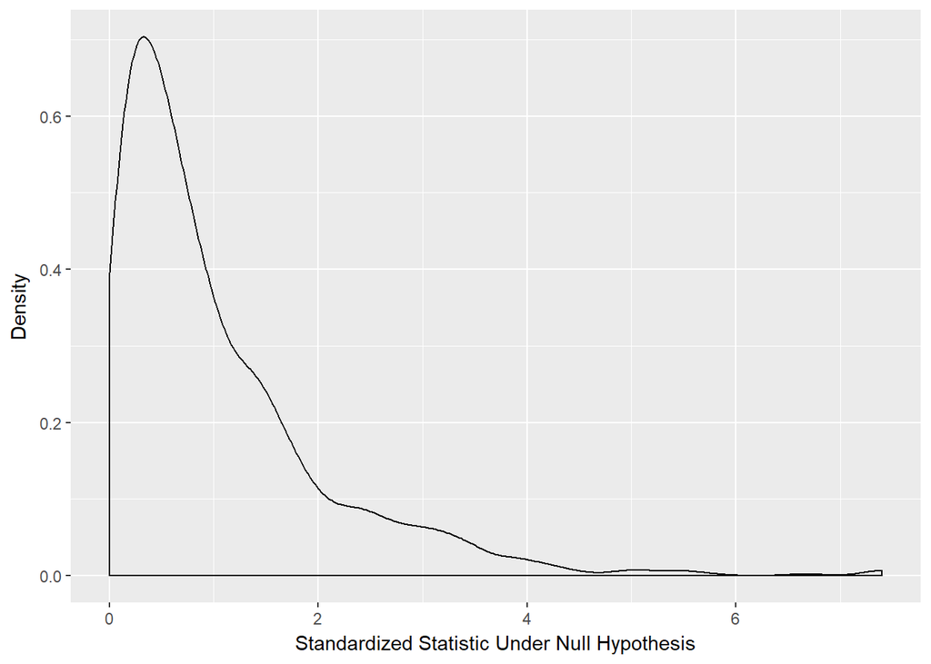

```r
> # Look at Entire Null Distribution
> qplot(data = null.distn,
+       x = statistic,
+       geom = "density",
+       xlab = "Standardized Statistic Under Null Hypothesis",
+       ylab = "Density")
```